# Students' Academic Performance

## Preliminary Wrangling

> This is an educational data set which is collected from learning management system (LMS) called Kalboard 360. Kalboard 360 is a multi-agent LMS, which has been designed to facilitate learning through the use of leading-edge technology. Such system provides users with a synchronous access to educational resources from any device with Internet connection.  
> The data is collected using a learner activity tracker tool, which called experience API (xAPI). The xAPI is a component of the training and learning architecture (TLA) that enables to monitor learning progress and learner’s actions like reading an article or watching a training video. The experience API helps the learning activity providers to determine the learner, activity and objects that describe a learning experience. The dataset consists of 480 student records and 16 features.  
> The features are classified into three major categories: (1) Demographic features such as gender and nationality. (2) Academic background features such as educational stage, grade Level and section. (3) Behavioral features such as raised hand on class, opening resources, answering survey by parents, and school satisfaction.

```python
# import all packages and set plots to be embedded inline
import numpy as np
import pandas as pd
import matplotlib.pyplot as plt
import seaborn as sb

%matplotlib inline
```

```python
# read the dataset to pandas dataframe
performance = pd.read_csv("Students' Academic Performance Dataset.csv")
```

```python
# display the first 10th rows of the data
performance.head(10)
```

|  | gender | NationalITy | PlaceofBirth | StageID | GradeID | SectionID | Topic | Semester | Relation | raisedhands | VisITedResources | AnnouncementsView | Discussion | ParentAnsweringSurvey | ParentschoolSatisfaction | StudentAbsenceDays | Class |
| --- | --- | --- | --- | --- | --- | --- | --- | --- | --- | --- | --- | --- | --- | --- | --- | --- | --- |
| 0 | M | KW | KuwaIT | lowerlevel | G-04 | A | IT | F | Father | 15 | 16 | 2 | 20 | Yes | Good | Under-7 | M |
| 1 | M | KW | KuwaIT | lowerlevel | G-04 | A | IT | F | Father | 20 | 20 | 3 | 25 | Yes | Good | Under-7 | M |
| 2 | M | KW | KuwaIT | lowerlevel | G-04 | A | IT | F | Father | 10 | 7 | 0 | 30 | No | Bad | Above-7 | L |
| 3 | M | KW | KuwaIT | lowerlevel | G-04 | A | IT | F | Father | 30 | 25 | 5 | 35 | No | Bad | Above-7 | L |
| 4 | M | KW | KuwaIT | lowerlevel | G-04 | A | IT | F | Father | 40 | 50 | 12 | 50 | No | Bad | Above-7 | M |
| 5 | F | KW | KuwaIT | lowerlevel | G-04 | A | IT | F | Father | 42 | 30 | 13 | 70 | Yes | Bad | Above-7 | M |
| 6 | M | KW | KuwaIT | MiddleSchool | G-07 | A | Math | F | Father | 35 | 12 | 0 | 17 | No | Bad | Above-7 | L |
| 7 | M | KW | KuwaIT | MiddleSchool | G-07 | A | Math | F | Father | 50 | 10 | 15 | 22 | Yes | Good | Under-7 | M |
| 8 | F | KW | KuwaIT | MiddleSchool | G-07 | A | Math | F | Father | 12 | 21 | 16 | 50 | Yes | Good | Under-7 | M |
| 9 | F | KW | KuwaIT | MiddleSchool | G-07 | B | IT | F | Father | 70 | 80 | 25 | 70 | Yes | Good | Under-7 | M |

```python
# get look on the data abont the datatype, number of columns and null values
performance.info()
```

```
<class 'pandas.core.frame.DataFrame'>
RangeIndex: 480 entries, 0 to 479
Data columns (total 17 columns):
 #   Column                    Non-Null Count  Dtype
---  ------                    --------------  -----
 0   gender                    480 non-null    object
 1   NationalITy               480 non-null    object
 2   PlaceofBirth              480 non-null    object
 3   StageID                   480 non-null    object
 4   GradeID                   480 non-null    object
 5   SectionID                 480 non-null    object
 6   Topic                     480 non-null    object
 7   Semester                  480 non-null    object
 8   Relation                  480 non-null    object
 9   raisedhands               480 non-null    int64
 10  VisITedResources          480 non-null    int64
 11  AnnouncementsView         480 non-null    int64
 12  Discussion                480 non-null    int64
 13  ParentAnsweringSurvey     480 non-null    object
 14  ParentschoolSatisfaction  480 non-null    object
 15  StudentAbsenceDays        480 non-null    object
 16  Class                     480 non-null    object
dtypes: int64(4), object(13)
memory usage: 63.9+ KB
```

### What is the structure of your dataset?

> 17 columns, show the data:

> ```
> - Number of Instances: 480 <br>
> - Area: E-learning, Education, Predictive models, Educational Data Mining <br>
> - Attribute Characteristics: Integer/Categorical <br>
> - Number of Attributes: 16 <br>
> - Missing Values? No
> ```

### What is/are the main feature(s) of interest in your dataset?

> Features:

> ```
> - Relation(Father or Mother). <br>
> - Announcements View. <br>
> - Parent Answering Survey. <br>
> - Parent School Satisfaction. <br>
> - Topic.
> ```

### What features in the dataset do you think will help support your investigation into your feature(s) of interest?

> - Relation(Father or Mother).
> - Parent School Satisfaction.
> - Topic.

## Univariate Exploration

```python
# define function for sb.countplot function
def countplot(data, x, title, xlabel):
    """create countplot with seaborn package"""
    sb.countplot(data = data, x = x, color = sb.color_palette()[0])
    plt.title(title)
    plt.xlabel(xlabel)
    return plt.show()
```

```
The number of male = 305
```

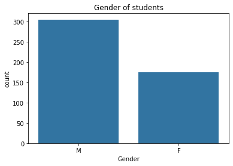

```python
# find the number of male to the female in the dataset
print('The number of male =', performance.query("gender == 'M'").value_counts().sum())

# visualize the number of the male and female
countplot(performance, 'gender', 'Gender of students', 'Gender')
```

```
Father    283
Mum       197
Name: Relation, dtype: int64
```

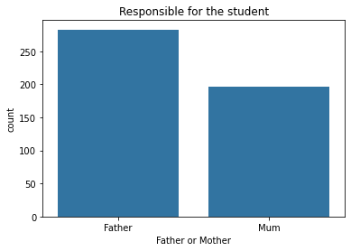

```python
# find the numbers each class in the dataset
print(performance.Relation.value_counts())

# visualize the Class column
student_class = countplot(performance, 'Relation', 'Responsible for the student', 'Father or Mother')
```

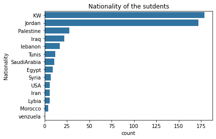

```python
# Visualze the natioaity of the students
frequance = performance.NationalITy.value_counts()
nationality_order = frequance.index
sb.countplot(data = performance, y = 'NationalITy', color = sb.color_palette()[0], order = nationality_order)
plt.title('Nationality of the sutdents')
plt.ylabel('Nationality');
```

```python
# show the number of natioaity of the students
performance.NationalITy.value_counts()
```

```
KW             179
Jordan         172
Palestine       28
Iraq            22
lebanon         17
Tunis           12
SaudiArabia     11
Egypt            9
Syria            7
USA              6
Iran             6
Lybia            6
Morocco          4
venzuela         1
Name: NationalITy, dtype: int64
```

> From the bar cahrt the **Kuwait and Jordan** student represent **73.125 %** of all nationality of students.

```
Yes    270
No     210
Name: ParentAnsweringSurvey, dtype: int64
```

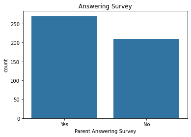

```python
# show the numbers of parent answering survey
print(performance.ParentAnsweringSurvey.value_counts())

# visualize ParentAnsweringSurvey column
countplot(performance, 'ParentAnsweringSurvey', 'Answering Survey', 'Parent Answering Survey')
```

### Discuss the distribution(s) of your variable(s) of interest. Were there any unusual points? Did you need to perform any transformations?

> No.

### Of the features you investigated, were there any unusual distributions? Did you perform any operations on the data to tidy, adjust, or change the form of the data? If so, why did you do this?

> I didn't do any operations.

## Bivariate Exploration

```python
# create function for sb.violinplot function
def violinplot(data, x , y):
    """create violinplot with seaborn package"""
    sb.violinplot(data = data, x = x, y = y, color = sb.color_palette()[0], inner = 'quartile')
```

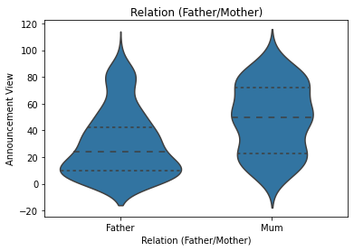

```python
# visualize the relationship between announcement view and relation(Responsible for the student from the parents)
violinplot(performance, 'Relation' , 'AnnouncementsView')

plt.title('Relation (Father/Mother)')
plt.xlabel('Relation (Father/Mother)')
plt.ylabel('Announcement View');
```

> Form the violinplot the **fathers** view announcement **23 times** -approximately- in the mean, but the **mothers** view the announcement **50 time** in the mean... which is twice the mean of parents.

```python
# put the data ('StudentAbsenceDays' & 'ParentschoolSatisfaction') in desirable format - a DataFram
parents_absence = performance.groupby(['StudentAbsenceDays', 'ParentschoolSatisfaction']).size()


parents_absence = parents_absence.reset_index(name = 'count')
parents_absence = parents_absence.pivot(index = 'StudentAbsenceDays', columns = 'ParentschoolSatisfaction',
                                        values = 'count')
```

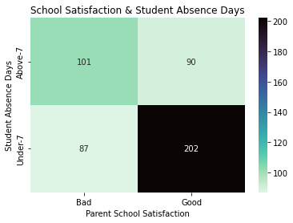

```python
# plot teh heatmap
sb.heatmap(parents_absence, annot = True, fmt = 'd', cmap = 'mako_r')

plt.title('School Satisfaction & Student Absence Days')
plt.xlabel('Parent School Satisfaction')
plt.ylabel('Student Absence Days');
```

> The heatmap show the stuednt absence under 7 days in the semester the parent is satisfied, and it is normal thing. on the other hand, when the student absence above 7 days in the semester the parent get bad, and also it is normal thing.  
> But I wonder about the two section of "Bad & Under-7" and "Good & Above-7", So, I will visualize the heatmap one more time in the multivariate section in below... but I will add the 'Relation' column to the figure to get more understand about this point.

```python
# put the data ('ParentschoolSatisfaction' & 'Relation') in desirable format - a DataFram

parents_absence_relation = performance.groupby(['Relation', 'ParentschoolSatisfaction']).size()


parents_absence_relation = parents_absence_relation.reset_index(
                                    name = 'StudentAbsenceDays')
parents_absence_relation = parents_absence_relation.pivot(index = 'Relation', columns = 'ParentschoolSatisfaction',
                                                          values = 'StudentAbsenceDays')
```

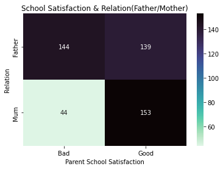

```python
# plot heatmap
sb.heatmap(parents_absence_relation, annot = True, fmt = 'd', cmap = 'mako_r')

plt.title('School Satisfaction & Relation(Father/Mother)')
plt.xlabel('Parent School Satisfaction')
plt.ylabel('Relation');
```

```
Father    283
Mum       197
Name: Relation, dtype: int64
```

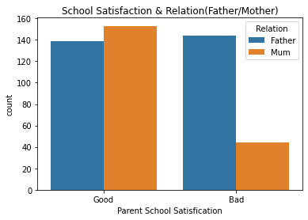

```python
# show the numbers of Father to mother
print(performance.Relation.value_counts())

sb.countplot(data = performance, x ='ParentschoolSatisfaction', hue = 'Relation')

plt.title('School Satisfaction & Relation(Father/Mother)')
plt.xlabel('Parent School Satisfication');
```

> The bar cahrts from the previous figurs show that... the 50% -approximately- of father satisfied about the school... and the other not fully satisfied, So the propotion is 1:1. The same propotion about the student absence days through the semester.  
> On the other hand, the the proportion of mothers is 3:1 (Good:bad). Also, the same thing here about the propotion about the student absence days through the semester.

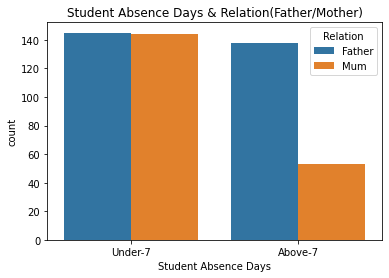

```python
# Visualze Student Absence Days and Relation
sb.countplot(data = performance, x ='StudentAbsenceDays', hue = 'Relation')

plt.title('Student Absence Days & Relation(Father/Mother)')
plt.xlabel('Student Absence Days');
```

```
M    211
H    142
L    127
Name: Class, dtype: int64
```

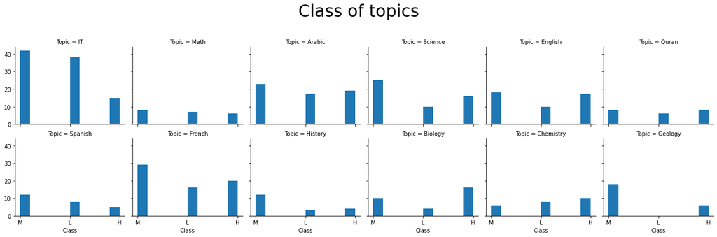

```python
# find the number of student in each class
print(performance.Class.value_counts())

# Visualze Student Topic Days and Class
graph = sb.FacetGrid(data = performance, col = 'Topic', col_wrap = 6)
graph.map(plt.hist, 'Class')

graph.fig.subplots_adjust(top = 0.8)
graph.fig.suptitle('Class of topics', fontsize = 30);
```

### Talk about some of the relationships you observed in this part of the investigation. How did the feature(s) of interest vary with other features in the dataset?

> From the visualization... The Relation which is resplsaple of parents (Father or Mother) affect on the state of the students which affects the parents’ evaluation of the school

### Did you observe any interesting relationships between the other features (not the main feature(s) of interest)?

> Yes.

## Multivariate Exploration

```python
# performance.groupby(by=
#                     ['ParentschoolSatisfaction','StudentAbsenceDays','Relation']
#                    ).count()

# sb.swarmplot(data = performance,
#              x = 'ParentschoolSatisfaction',
#              y ='StudentAbsenceDays',hue = 'Relation');
```

```python
# # show the numbers of Father to mother
# print(performance.Relation.value_counts())


# ax = sb.barplot(data = performance, x = 'ParentschoolSatisfaction',
#                 y = 'AnnouncementsView', hue = 'Relation')
# ax.legend(title = 'Parent Answering Survey');
```

```python
# sb.countplot(data = performance, y = 'Topic', hue = 'Class')
```

```python
# sb.countplot(data = performance, x = 'Class', hue = 'Topic', color = sb.color_palette()[0]);
```

```
IT           95
French       65
Arabic       59
Science      51
English      45
Biology      30
Spanish      25
Chemistry    24
Geology      24
Quran        22
Math         21
History      19
Name: Topic, dtype: int64
```

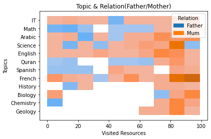

```python
# show the numbers of students in each topic
print(performance.Topic.value_counts())

# Visualze Student Topic and Relation
sb.histplot(data = performance, x = 'VisITedResources', y ='Topic', hue = 'Relation')

plt.title('Topic & Relation(Father/Mother)')
plt.xlabel('Visited Resources')
plt.ylabel('Topics');
```

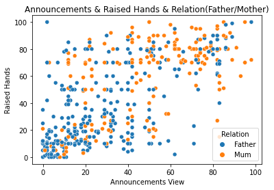

```python
# show the relationship between Announcements view and Reised hands and Relation(Father/Mohter)
sb.scatterplot(data = performance, x = 'AnnouncementsView', y = 'raisedhands', hue = 'Relation')

plt.title('Announcements & Raised Hands & Relation(Father/Mother)')
plt.xlabel('Announcements View')
plt.ylabel('Raised Hands');
```

> - In the most topic the most responsible of the parents in the father.
> - In English and French topics the most responsible is the mother.
> - IT and French topics The proportion between father and mum it have very varianc. IT is the thopic have the largest proporation of the father is responsible, and and French have teh larges proproation of the mother is responsible.

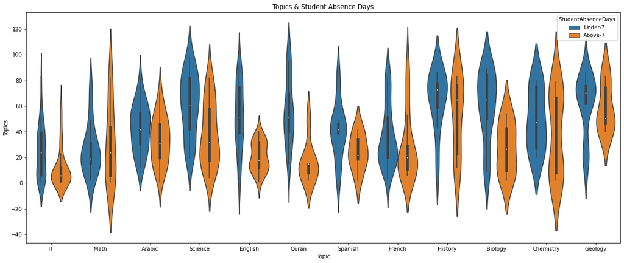

```python
# Visualze Student Absence Days and Relation
plt.figure(figsize = (20,8))
sb.violinplot(data = performance, y = 'AnnouncementsView', x ='Topic', hue = 'StudentAbsenceDays')
plt.title('Topics & Student Absence Days')
plt.ylabel('Topics');
```

```python
# put the data ('Topic' & 'Class') in desirable format - a DataFram
topic_class = performance.groupby(['Topic', 'ParentschoolSatisfaction']).size()


topic_class = topic_class.reset_index(name = 'count')
topic_class = topic_class.pivot(index = 'Topic', columns = 'ParentschoolSatisfaction',values = 'count')
```

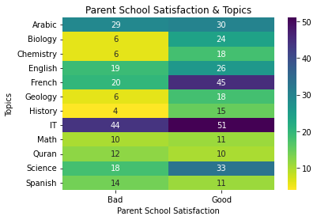

```python
# plot heatmap
sb.heatmap(topic_class, annot = True, cmap = 'viridis_r')

plt.title('Parent School Satisfaction & Topics')
plt.xlabel('Parent School Satisfaction')
plt.ylabel('Topics');
```

> - Spanish and Quran topic have Bad Satisfaction more than Good unlike other topics.

### Were there any interesting or surprising interactions between features?

> The absent days of the student affect on the satisfication of the parent about the school.

> At the end of your report, make sure that you export the notebook as an html file from the `File > Download as... > HTML` menu. Make sure you keep track of where the exported file goes, so you can put it in the same folder as this notebook for project submission. Also, make sure you remove all of the quote-formatted guide notes like this one before you finish your report!